# Group Empathy Theory: The Effect of Group Empathy on US Intergroup Attitudes and Behavior in the Context of Immigration Threats

Cigdem V. Sirin, Nicholas A. Valentino & José D. Villalobos

The Journal of Politics (2016) · Presented by Ago Echeverri

2026-10-27

## The Puzzle

- Natives oppose immigration when immigrants compete for their jobs and wages (Malhotra, Margalit, and Mo 2013)
- E.g., U.S. tech workers oppose the H-1B visas that bring in workers like them.
- If so, the groups most exposed to competition should be the **most** opposed. African Americans face the most downward wage pressure from working-class immigrants (Gay 2006)
- Yet they are often **more** supportive of immigrants, and less moved by threatening appeals (Masuoka and Junn 2013)
- Latinos are also more supportive, but is that just **in-group affinity**? Little is known about how they view **non-Latino** immigrants

# Group Empathy Theory

## Theory

- Empathy felt by members of one group toward another can boost support for it, **even when the groups have competing interests**.
- Built on/inspired by Davis’s IRI (Davis 1983): **cognitive** empathy (perspective taking) and **affective** empathy (empathic concern), moved from the **interpersonal** to the **intergroup** level
- No shared identity, affinity, or linked fate required: empathy is triggered when an out-group’s treatment **mirrors the in-group’s history** of unfair treatment
- Minorities should empathize more: “double consciousness” makes perspective taking easier, and experience of discrimination builds *parallel* affect (feeling the target’s own anger)
- So group empathy can **override** realistic interests

## Hypotheses

- **H1**: African Americans and Latinos have higher **general** group empathy than Anglos, and higher empathy toward stigmatized out-groups and undocumented immigrants
- **H2**: In the experiment, they are more likely to **side with nonwhite detainees** and to see the officials’ decision as unreasonable, even when the detainee is from another group
- **H3**: … and more supportive of **civil rights policies** and **political action** for undocumented immigrants
- **H4**: Empathy toward undocumented immigrants **mediates** the Anglo–African American and Anglo–Latino differences

# Design

## Two Studies

Study 1 · Wave 1 survey

N = 1,799

633 Anglos · 614 African Americans · 552 Latinos (Knowledge Networks, Dec 2013)

**Measures:** group empathy (GEI and group-specific), threat, trust, competition, SDO, party

**Tests:** H1

→7–10 days  
later

Study 2 · Wave 2 experiment

N = 671

244 Anglos · 217 African Americans · 210 Latinos (subsample of Study 1)

**Randomized:** the photo of a detainee (white, Arab, black, Latino)

**Outcomes:** side with detainee · denial unreasonable · policies · action

**Tests:** H2–H3, and H4 with Study 1's empathy as the mediator

- Plus three side studies: GEI validation (MTurk, N = 300), photo check (MTurk, N = 125), linked fate (KN, N = 621). All tests **one-tailed**

## Study 1: Measuring Group Empathy

|  | Davis’s IRI (individual) | Group Empathy Index (group) |
| --- | --- | --- |
| Empathic concern | “I often have tender, concerned feelings for people less fortunate than me.” | “I often have tender, concerned feelings for people **from another racial or ethnic group** who are less fortunate than me.” |
| Perspective taking | “Before criticizing somebody, I try to imagine how I would feel if I were in their place.” | “Before criticizing somebody **from another racial or ethnic group**, I try to imagine how I would feel if I were in their place.” |

- 7 + 7 items, α = .84. **Validated** against the IRI (MTurk, N = 300): only the GEI predicts opposition to punitive immigration policies; it also predicts confronting racist jokes, unlike SDO, authoritarianism, or ethnocentrism
- **Group-specific empathy** for nine groups, incl. **undocumented immigrants**: “How concerned do you feel about the challenges they face?” + “How easy is it to ‘put yourself in the shoes’ of [group]?” This two-item measure, not the GEI, is **H4’s mediator**

## Study 2: Vignette

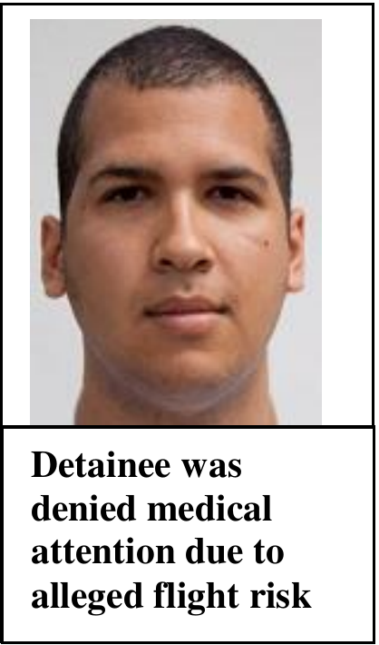

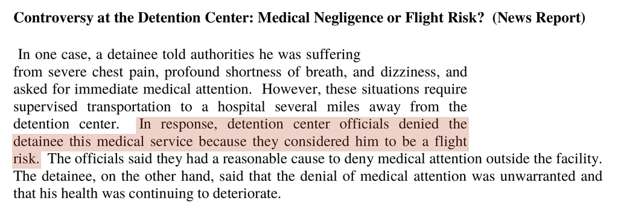

- A “randomly selected” **news report**: an **ambiguous** incident, negligence or flight risk? (Peffley and Hurwitz 2010)
- Only the **photo** changes; the text never names the detainee’s race or origin

## Study 2: Faces

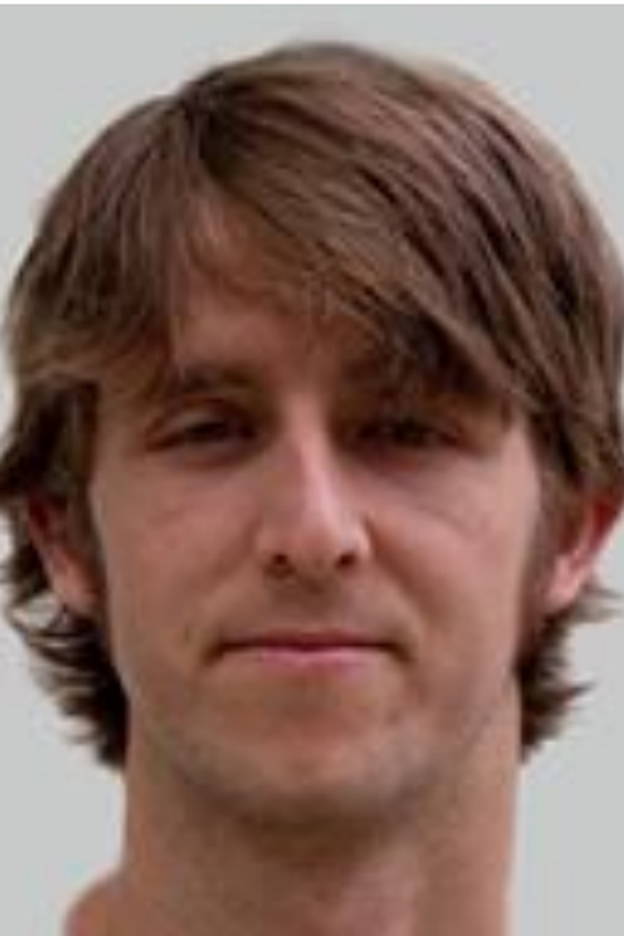

White

rated 4.88 · 100% correct

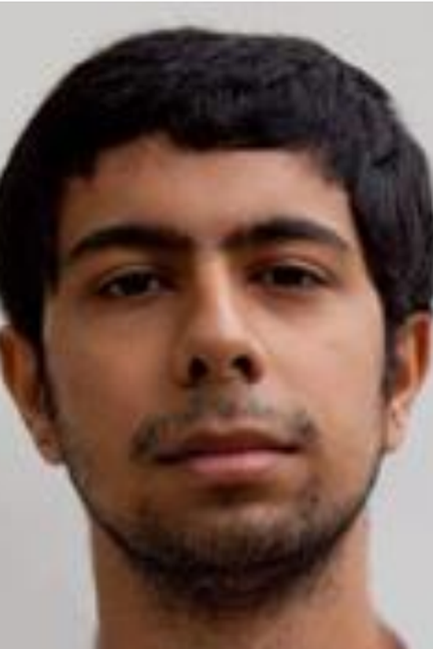

Arab

rated 3.71 · 85% correct

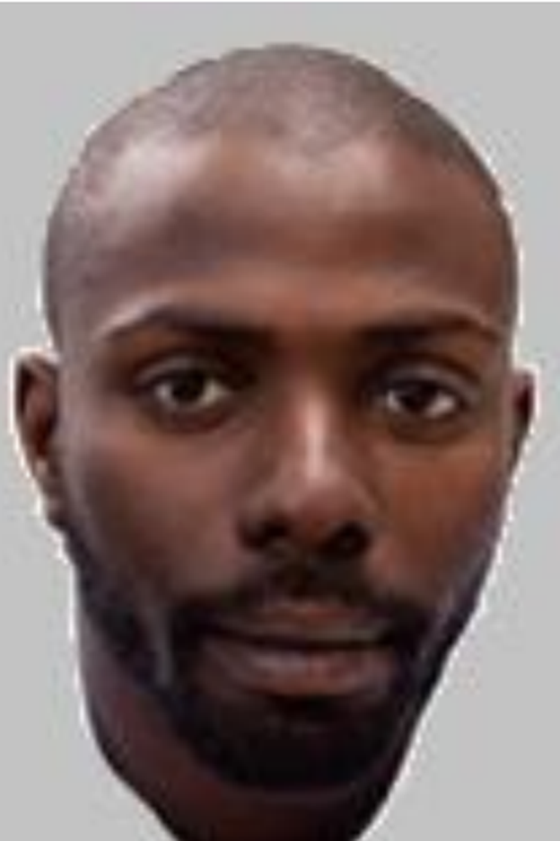

Black

rated 4.74 · >99% correct

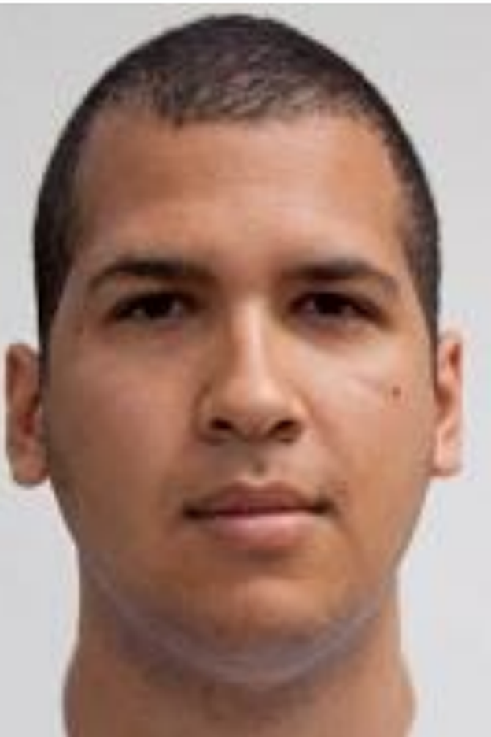

Latino

rated 3.61 · 82% correct

- Chosen from 40 photos by 8 judges naïve to the hypotheses (intended race, 1–5; identification check on MTurk, N = 125)
- Equated on friendly, attractive, well-off, law-abiding, educated, trustworthy: differences ≤ .4, n.s.

# What They Find

## Study 1 · H1: Empathy by Group

[figure not shown]

- Minorities: higher general **and** group-specific empathy, yet **as empathic toward Anglos** as Anglos themselves. African Americans also perceive **more** economic competition (.48 vs. .43)

## Study 2 · H2–H3: The Experiment

[figure not shown]

- African Americans side with the **Latino** detainee, their main economic competitor (.67 vs. .45 for Anglos). **Latinos** are above Anglos everywhere but don’t respond to the cue

## Studies 1 + 2 · H4: Mediation

- GSEM probit: race → **empathy for undocumented immigrants** (Study 1) → outcome (Study 2), controlling for threat and trust

| % mediated | Side | Unreasonable | Policies | Behavior |
| --- | --- | --- | --- | --- |
| African Americans | 53% | 62% | 75% | 66% |
| Latinos | 72% | 78% | 61% | 56% |

- With extended controls (SDO, authoritarianism, PID, discrimination): **“full”** mediation
- **Linked fate** (Dawson 1995), separate sample (N = 621): minorities feel no more linked fate with other minorities than with Anglos
- **Threat** and **trust**: no indirect effects. Conclusion: empathy, not threat, explains the **gaps between groups**

## Authors’ Conclusions

- Group empathy is a distinct, measurable, **politically potent** construct, different from individual trait empathy
- Minorities show more of it, and it explains their reactions to immigration threats **better than threat does**.
- African Americans side with **Latino** detainees, their main economic competitors, contrary to the interminority conflict view: room for **Black–Latino coalitions**

# Discussion

## 1. One Face per Race

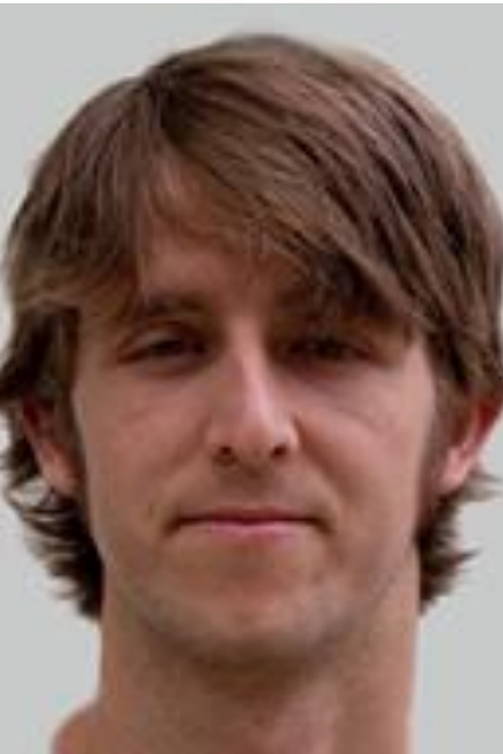

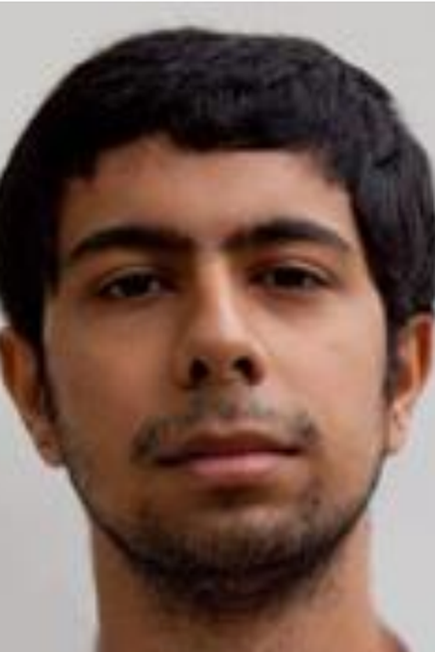

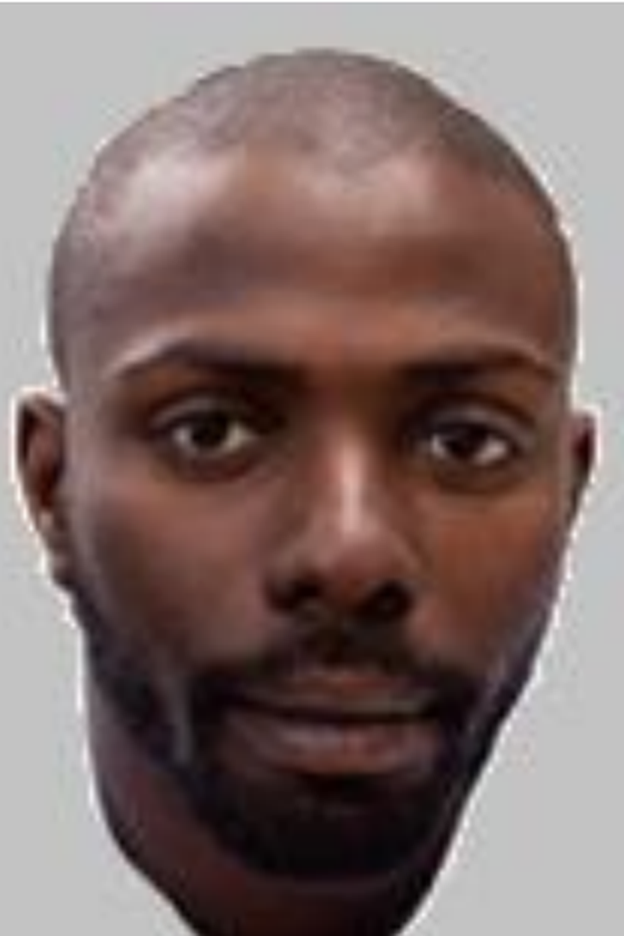

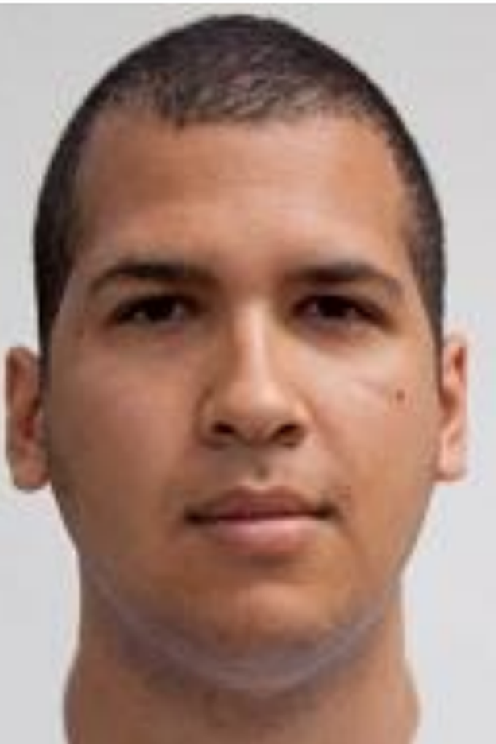

- If there is only one face per race, we cannot separate race effects from the face (Wells and Windschitl 1999). Judges also did not rate what face databases norm: **threat**, **anger**, happiness, age (Ma, Correll, and Wittenbrink 2015), nor aggressiveness or diligence
- Hair, facial hair, and expression differ (only the white face is close to a smile): the faces may read as more or less **agreeable** or **aggressive**
- Any given effect may be a threat or agreeableness effect: the counterfactual (same face, other race) is never observed

## 2. Is It Empathy?

- The mediator asks how concerned people are about undocumented immigrants; the outcomes are support for undocumented immigrants
- Zaki and Ochsner (2012) separate **experience sharing**, **mentalizing**, and **prosocial concern**. Nothing here taps experience sharing, the core of the theory’s “parallel” empathy
- Empathy is **motivated** (Zaki 2014): people approach or avoid it depending on their goals, including group identity. Empathy for undocumented immigrants can be a **consequence** of political commitments, not only a cause
- What they measure may be closer to **sympathy or solidarity**. The puzzle still stands

## 3. The Mediation Is Inflated

[figure not shown]

- The paper multiplies an **a** estimated in **Study 1** (all 1,776 respondents, ordered-probit **latent** scale) by a **b** from **Study 2** (~650, **observed** scale)
- Attrition from Study 1 to Study 2 is never assessed
- If we keep only the sample of Study 2: **22–44%** for African Americans (reported 53–75%), **20–41%** for Latinos (reported 56–78%)

## 4. The Gap Is Partisan

Racial gap vs. Anglos (African Am. / Latinos), linear, same sample

| Controls | Side | Unreasonable | Policies | Behavior |
| --- | --- | --- | --- | --- |
| Fig. 5 | .12 / .09 | .10 / .09 | .06 / .10 | .15 / .20 |
| + Democrat | .06 / .05 | .04 / .06 | .01 / .07 | .08 / .16 |
| + SDO, ideo., Dem. | .03 / .04 | .02 / .06 | −.01 / .07 | .06 / .16 |

- One Democrat dummy **halves** the African American gap
- As a “mediator” in the same model, Democrat accounts for **44–86%** of the African American gap, more than any other measure
- The decomposition can’t tell empathy from partisanship (Imai et al. 2011)

## Critical Assessment

Positives:

**A clear contribution**: moves empathy from the interpersonal to the **intergroup** level and offers a concrete answer to a real puzzle: why the group most exposed to competition is the most supportive.

**Builds carefully on prior work**: Davis’s IRI, empathy and prejudice reduction, realistic interests, coalitions… Even if we doubt that what they measure is empathy in Zaki’s sense, the new construct is well grounded in that literature.

**Very good validation of the scale**: GEI vs. IRI randomized head to head; predictive validity (racist jokes, rallies); discriminant validity against SDO, authoritarianism, and ethnocentrism.

## Critical Assessment

Negatives:

**The experiment supports the theory for African Americans only**, and some tests rely on one-tailed tests

**The mechanism is overstated**: empathy toward undocumented immigrants accounts for ~20–45% of the gap, not 53–78%; partisanship accounts for as much; and empathy does not moderate the cue among minorities.

**Is it empathy?** A self-reported concern for the very group the outcomes are about, possibly a consequence of political commitments (Zaki 2014).

## Questions

- Is group empathy a **cause** of immigration attitudes, or a **consequence** of them (and of partisanship)? How could we tell with these data?
- On *Seeing Us in Them* (their later book), they claim that identitarian pathways to coalitions are not viable (like People of Color Identity). Do you agree with this take?
- How viable do you think this mechanism is to explore majority/minority relations?

## References

Davis, Mark H. 1983. “Measuring Individual Differences in Empathy: Evidence for a Multidimensional Approach.” *Journal of Personality and Social Psychology* 44 (1): 113–26.

Dawson, Michael C. 1995. *Behind the Mule: Race and Class in African American Politics*. Princeton, NJ: Princeton University Press.

Gay, Claudine. 2006. “Seeing Difference: The Effect of Economic Disparity on Black Attitudes Toward Latinos.” *American Journal of Political Science* 50 (4): 982–97.

Imai, Kosuke, Luke Keele, Dustin Tingley, and Teppei Yamamoto. 2011. “Unpacking the Black Box of Causality: Learning about Causal Mechanisms from Experimental and Observational Studies.” *American Political Science Review* 105 (4): 765–89.

Ma, Debbie S., Joshua Correll, and Bernd Wittenbrink. 2015. “The Chicago Face Database: A Free Stimulus Set of Faces and Norming Data.” *Behavior Research Methods* 47: 1122–35.

Malhotra, Neil, Yotam Margalit, and Cecilia Hyunjung Mo. 2013. “Economic Explanations for Opposition to Immigration: Distinguishing Between Prevalence and Conditional Impact.” *American Journal of Political Science* 57 (2): 391–410.

Masuoka, Natalie, and Jane Junn. 2013. *The Politics of Belonging: Race, Public Opinion, and Immigration*. Chicago, IL: University of Chicago Press.

Peffley, Mark, and Jon Hurwitz. 2010. *Justice in America: The Separate Realities of Blacks and Whites*. New York, NY: Cambridge University Press.

Wells, Gary L., and Paul D. Windschitl. 1999. “Stimulus Sampling and Social Psychological Experimentation.” *Personality and Social Psychology Bulletin* 25 (9): 1115–25.

Zaki, Jamil. 2014. “Empathy: A Motivated Account.” *Psychological Bulletin* 140 (6): 1608–47.

Zaki, Jamil, and Kevin N. Ochsner. 2012. “The Neuroscience of Empathy: Progress, Pitfalls and Promise.” *Nature Neuroscience* 15 (5): 675–80.